# Butterfly Data

Chris Terry

2026-07-09

# Introduction

This document processes the raw UKBMS data as available online, filtering it to focal sites, species and time period, and calculating into motifs of each window.

It also includes a large number of informal summary graphs to get a basic understanding of the data.

### Butterfly Data sources:

Botham, M.S.; Middlebrook, I.; Harrower, C.A.; Milborrow, J.; Roy, D.B. (2025). United Kingdom Butterfly Monitoring Scheme: site indices 2024. NERC EDS Environmental Information Data Centre. https://doi.org/10.5285/53a1c705-4437-48bb-9bcd-b68977f8edd9

Botham, M.S.; Middlebrook, I.; Heywood, J.; Harrower, C.A.; Milborrow, J.; Roy, D.B. (2025). United Kingdom Butterfly Monitoring Scheme: site location data 2024. NERC EDS Environmental Information Data Centre. https://doi.org/10.5285/d7256b49-f2e3-4ae7-907d-af729610c768

UK Butterfly Monitoring Scheme (UKBMS) data © copyright and database right Butterfly Conservation, the UK Centre for Ecology & Hydrology, British Trust for Ornithology, and the Joint Nature Conservation Committee.

```r
library(tidyverse)
library(sf)
library(terra)
library(rnaturalearth)
library(tidyterra)
library(patchwork)
SiteIndices <- read_csv( 'Butterfly Data/SiteIndices/data/ukbmssiteindices2024.csv')
LocationData <- read_csv( 'Butterfly Data/LocationData/data/ukbmssitelocationdata2024.csv')
```

# Data Inspection

Notes from UKBMS pages:

*The UKBMS relies on the creation of abundance indices, i.e. based on the number of individual butterflies recorded in transect sections and sites. These indices are a relative rather than an absolute measure of the size of a population. The site index reflects a more or less constant proportion of the number of butterflies present, although the proportion seen is likely to vary according to species; some butterfly species, such as Marbled White are conspicuous, whereas others such as Dingy Skipper are much less likely to be detected. Indices have been shown to relate closely to other, more intensive, measures of population size such as mark, release, recapture (MRR) methods*.

*This dataset comprises individual site indices for UK butterfly species calculated from data from the UK Butterfly Monitoring Scheme (UKBMS). Site indices are a relative rather than an absolute measure of the size of a population, and have been shown to relate closely to other, more intensive, measures of population size such as mark, release, recapture (MRR) methods. The site index can be thought of as a relative measure of the population size, being a more or less constant proportion of the number of butterflies present. The proportion seen is likely to vary according to species; some butterfly species are more conspicuous and thus more easily detected, whereas others are much less easy to see.*

NB ‘-2’ flag indicates *“a species was recorded at a given site in a given year but the site was not monitored sufficiently within the flight period of that species in that year to calculate an accurate site index”*

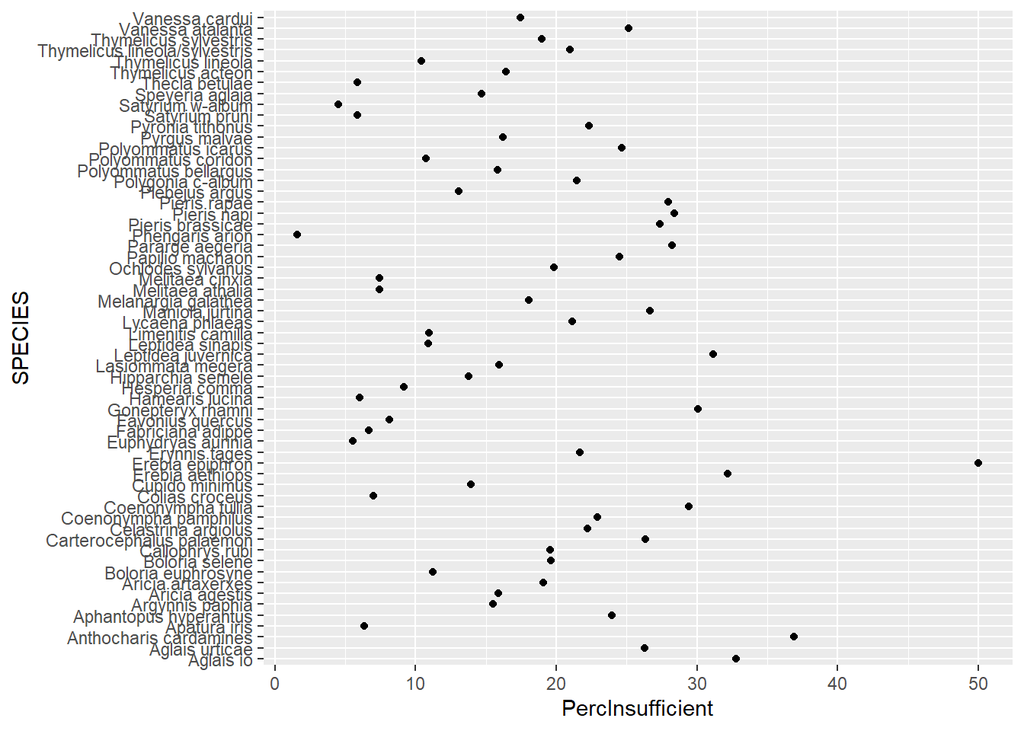

```r
SiteIndices %>%
  group_by(SPECIES) %>%
  summarise(PercInsufficient = 100*mean( SITE_INDEX == -2)) %>%
  ggplot(aes( y = SPECIES, x = PercInsufficient ))+
  geom_point()
```

Where a species has *never* been seen at a site, there is no entry. This results in radically different number of observations per species:

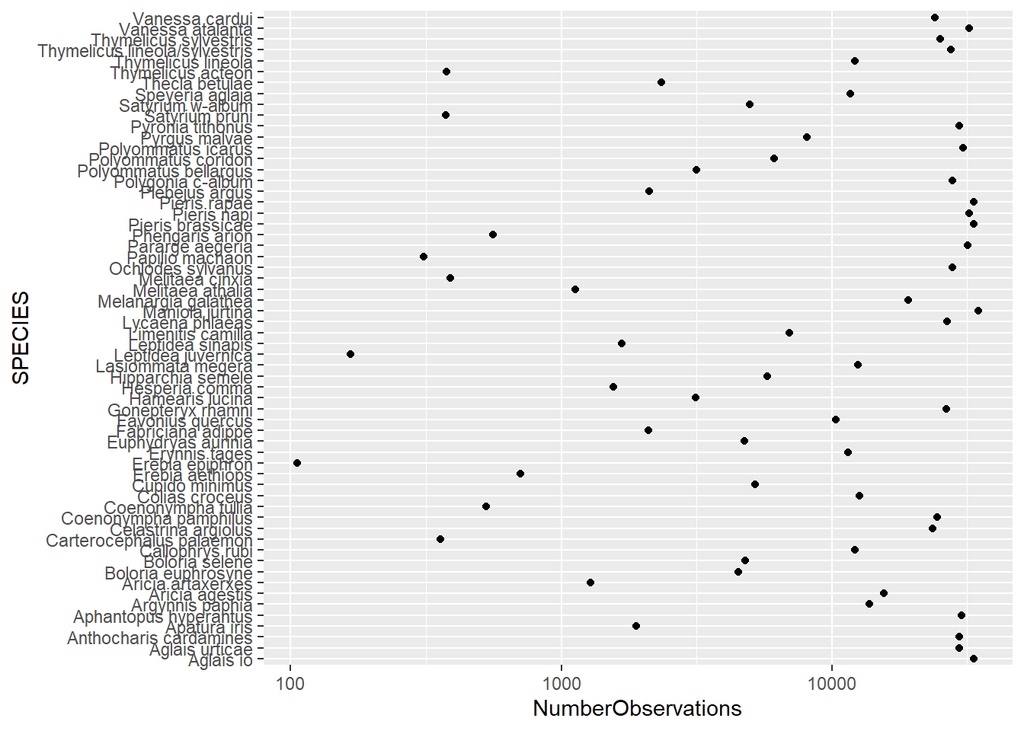

```r
SiteIndices %>%
  count(SPECIES, name = 'NumberObservations') %>%
  ggplot(aes( y = SPECIES, x = NumberObservations ))+
  geom_point()+
  scale_x_log10()
```

## Number of sites species seen at

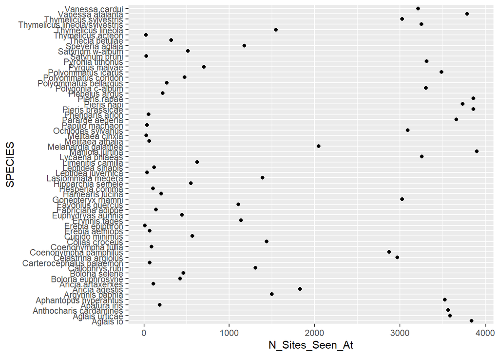

```r
SiteIndices %>%
  distinct(SITE_CODE , SPECIES) %>%
  count(SPECIES, name = 'N_Sites_Seen_At') %>%
  ggplot(aes( y = SPECIES, x = N_Sites_Seen_At ))+
  geom_point()
```

## Percentage of ‘true-zero’ observations.

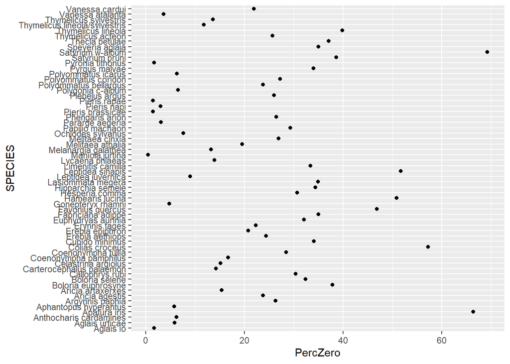

```r
SiteIndices %>%
  group_by(SPECIES) %>%
  summarise(PercZero = 100*mean( SITE_INDEX == 0)) %>%
  ggplot(aes( y = SPECIES, x = PercZero ))+
  geom_point()
```

## Max values

Some very large outliers, in all species. ‘Large blue’ has largest skew - makes sense as very localised.

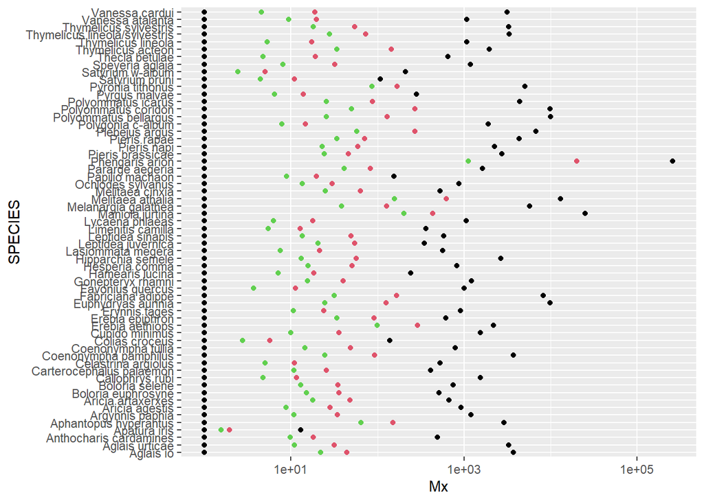

```r
SiteIndices %>%
  group_by(SPECIES) %>%
  filter( SITE_INDEX>0) %>%
  summarise(Mx = max( SITE_INDEX),
            Mn = min(SITE_INDEX ),
            Av = mean( SITE_INDEX),
            GeoAv = exp(mean(log(SITE_INDEX)))) %>%
  ggplot(aes( y = SPECIES))+
  geom_point(aes(x = Mx ))+
  geom_point(aes(x = Mn ))+
  geom_point(aes(x = Av ), col = 2)+
  geom_point(aes(x = GeoAv ), col = 3)+
  scale_x_log10()
```

### Sum per site / time

Measure is a relative measure per site. How constant is the sum of site indices? Most cluster around 1000 total units of relative abundance, but a considerable distribution around this.

```r
SiteIndices %>%
  filter(SITE_INDEX >0 ) %>%
  group_by(SITE_CODE , YEAR) %>%
  summarise(Sum_SiteIndex = sum(SITE_INDEX )) -> xxx
```

```
## `summarise()` has regrouped the output.
## ℹ Summaries were computed grouped by SITE_CODE and YEAR.
## ℹ Output is grouped by SITE_CODE.
## ℹ Use `summarise(.groups = "drop_last")` to silence this message.
## ℹ Use `summarise(.by = c(SITE_CODE, YEAR))` for per-operation grouping
##   (`?dplyr::dplyr_by`) instead.
```

```r
filter(xxx, Sum_SiteIndex > 100000)
```

```
## # A tibble: 28 × 3
## # Groups:   SITE_CODE [4]
##    SITE_CODE  YEAR Sum_SiteIndex
##        <dbl> <dbl>         <dbl>
##  1     20002  2002        122803
##  2     20002  2003        132367
##  3     20002  2004        137208
##  4     20002  2005        145440
##  5     20002  2006        129442
##  6     20002  2010        138112
##  7     20002  2012        131119
##  8     20002  2016        153073
##  9     20002  2017        173651
## 10     20002  2018        251961
## # ℹ 18 more rows
```

```r
SiteIndices %>%
  arrange(desc(SITE_INDEX ))
```

```
## # A tibble: 821,300 × 7
##    SITE_CODE COUNTRY SPECIES_CODE SPECIES         COMMON_NAME  YEAR SITE_INDEX
##        <dbl> <chr>          <dbl> <chr>           <chr>       <dbl>      <dbl>
##  1     20008 England           73 Phengaris arion Large Blue   2019     257446
##  2     20002 England           73 Phengaris arion Large Blue   2018     251961
##  3     20008 England           73 Phengaris arion Large Blue   2022     230652
##  4     20008 England           73 Phengaris arion Large Blue   2023     225569
##  5     20002 England           73 Phengaris arion Large Blue   2023     222633
##  6     20002 England           73 Phengaris arion Large Blue   2017     173651
##  7     20008 England           73 Phengaris arion Large Blue   2018     165931
##  8     20002 England           73 Phengaris arion Large Blue   2022     165372
##  9     20002 England           73 Phengaris arion Large Blue   2016     153073
## 10     20002 England           73 Phengaris arion Large Blue   2020     150664
## # ℹ 821,290 more rows
```

```r
SiteIndices %>%
  filter(SITE_INDEX >10000 ) %>%
  count( COMMON_NAME  )
```

```
## # A tibble: 3 × 2
##   COMMON_NAME          n
##   <chr>            <int>
## 1 Heath Fritillary     6
## 2 Large Blue         141
## 3 Meadow Brown        10
```

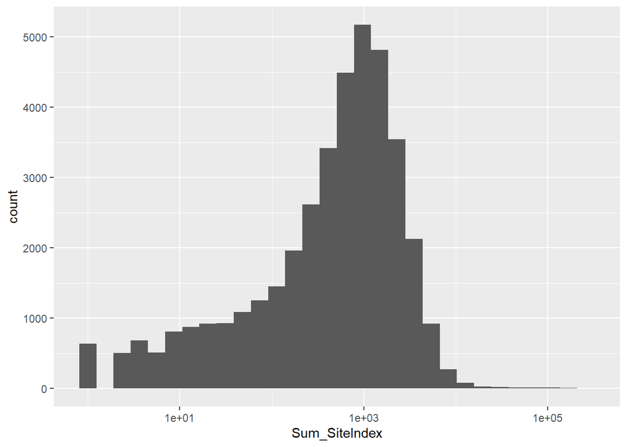

```r
xxx %>%
  ggplot(aes(Sum_SiteIndex ))+
  geom_histogram()+
  scale_x_log10()
```

## Duplicates

Cases where multiple different values given for same species / site / year.

Top two are of non-resident migrants, (*Vanessa cardui*, *Vanessa atalanta*) so probably will be excluded from eventual analyses anyway. Where there are multiple measurements that differ, for now will just exclude as unreliable.

```r
SiteIndices %>%
  add_count( SITE_CODE,  SPECIES,  YEAR) %>%
  add_count( SITE_CODE,  SPECIES,  YEAR,SITE_INDEX,
             name = 'N2' ) %>%
  filter(n>1 ) -> duplicate_site_year_sp

duplicate_site_year_sp%>%
  count( SPECIES ,sort = TRUE)
```

```
## # A tibble: 34 × 2
##    SPECIES                n
##    <chr>              <int>
##  1 Vanessa cardui       290
##  2 Vanessa atalanta     222
##  3 Pieris rapae         218
##  4 Maniola jurtina      178
##  5 Pyronia tithonus     176
##  6 Polyommatus icarus   168
##  7 Pieris brassicae     158
##  8 Pararge aegeria      156
##  9 Aglais io            122
## 10 Lycaena phlaeas      122
## # ℹ 24 more rows
```

```r
## Only get the issue in a subset of years, especially 2004-2007
duplicate_site_year_sp%>%
  count(YEAR ,sort = TRUE)
```

```
## # A tibble: 9 × 2
##    YEAR     n
##   <dbl> <int>
## 1  2006   816
## 2  2005   676
## 3  2004   646
## 4  2007   456
## 5  2023   184
## 6  2001     2
## 7  2002     2
## 8  2008     2
## 9  2018     2
```

```r
## In some cases both options are the same, so can safely use it
duplicate_site_year_sp %>%
  filter( N2 ==2)
```

```
## # A tibble: 2,686 × 9
##    SITE_CODE COUNTRY SPECIES_CODE SPECIES     COMMON_NAME  YEAR SITE_INDEX     n
##        <dbl> <chr>          <dbl> <chr>       <chr>       <dbl>      <dbl> <int>
##  1       135 England          123 Vanessa ca… Painted La…  2023          0     2
##  2       135 England          123 Vanessa ca… Painted La…  2023          0     2
##  3      1039 England          123 Vanessa ca… Painted La…  2023          0     2
##  4      1039 England          123 Vanessa ca… Painted La…  2023          0     2
##  5      1055 England          123 Vanessa ca… Painted La…  2023          0     2
##  6      1055 England          123 Vanessa ca… Painted La…  2023          0     2
##  7      1060 England          123 Vanessa ca… Painted La…  2023          0     2
##  8      1060 England          123 Vanessa ca… Painted La…  2023          0     2
##  9      1081 England          123 Vanessa ca… Painted La…  2023          0     2
## 10      1081 England          123 Vanessa ca… Painted La…  2023          0     2
## # ℹ 2,676 more rows
## # ℹ 1 more variable: N2 <int>
```

# Example Species Trends

```
## `geom_line()`: Each group consists of only one observation.
## ℹ Do you need to adjust the group aesthetic?
```

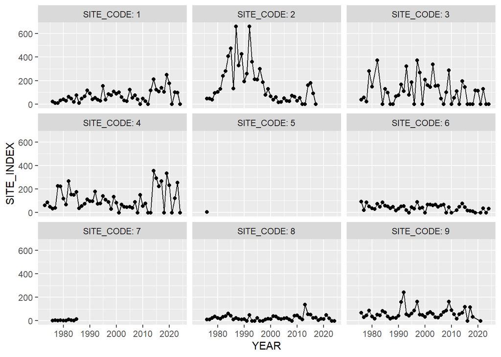

```r
SiteIndices %>%
  filter(COMMON_NAME == 'Peacock') %>%
  filter( SITE_CODE <10) %>%
  ggplot( aes (x = YEAR, y = SITE_INDEX, group =SITE_CODE))+
  geom_line()+
  geom_point()+
  facet_wrap( ~SITE_CODE,labeller = label_both)
```

### Distribution of Site data

Many sites have less than 10 years of surveys. Take quite a long cut-off to thin data before more precise processing

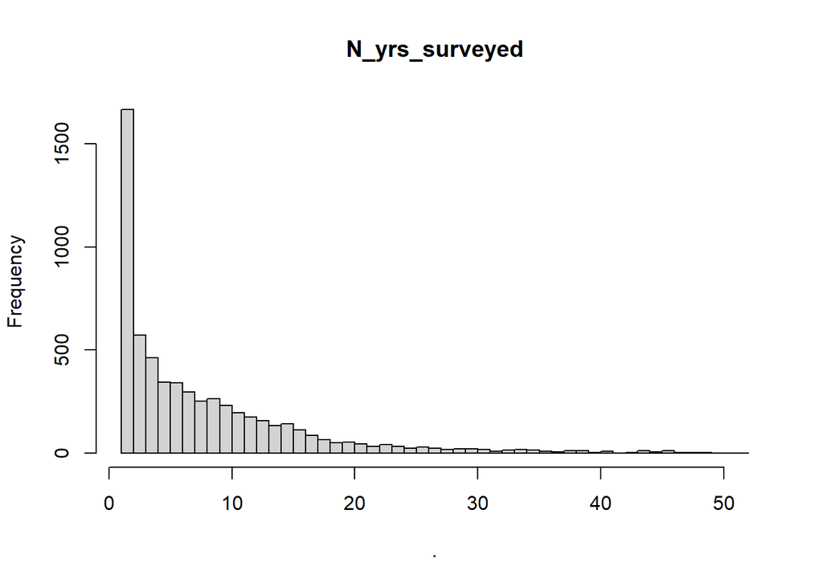

```r
LocationData$N_yrs_surveyed %>% hist(main = 'N_yrs_surveyed' , nclass = 60)
```

```r
LocationData$Survey_type %>% table
```

```
## .
## UKBMS  WCBS
##  3756  2326
```

```r
# 529 more than 20 years
sum(LocationData$N_yrs_surveyed >= 20)
```

```
## [1] 529
```

### Species Distribution

Want species that are in a reasonable number of long time series

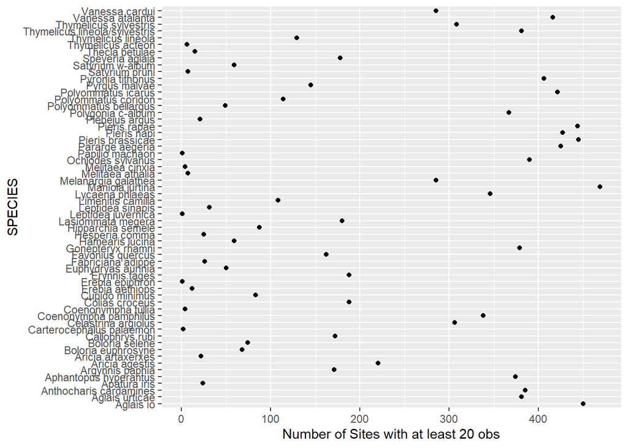

```r
LocationData %>%
  filter(N_yrs_surveyed >= 20 ) -> LocsTwentyObs

## Distribution of sites per species with obs (including zero)
LocsTwentyObs %>%
  left_join(SiteIndices,
            by = c('Site_Number' = 'SITE_CODE')) %>%
  count(Site_Number ,SPECIES   ) %>%
  filter( n>=20) %>%
  count(SPECIES ,
        name = 'Number of Sites with at least 20 obs') %>%
  ggplot(aes( y = SPECIES, x = `Number of Sites with at least 20 obs`))+
  geom_point()
```

### Spatial Distibution of 20+ Years Sites

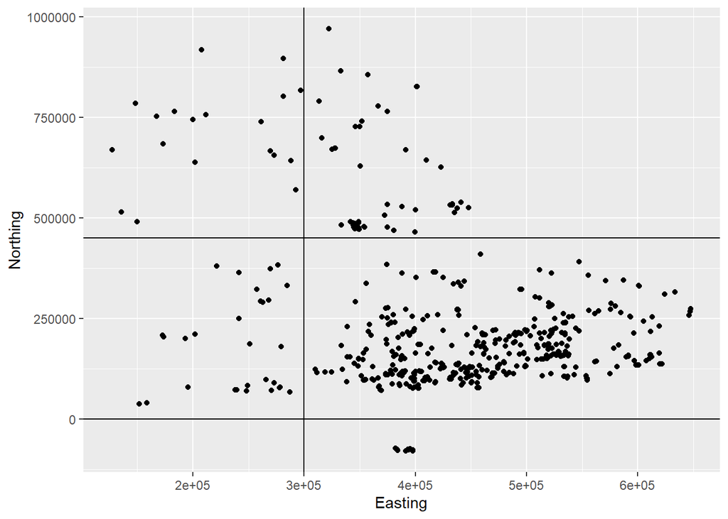

```r
LocsTwentyObs %>%
  ggplot(aes( x = Easting, y= Northing)) +
  geom_point()+
  geom_hline(yintercept = 450000)+
  geom_hline(yintercept = 0)+
  geom_vline(xintercept = 300000)
```

### Time Period

Tail of data at start. Enough by 1976

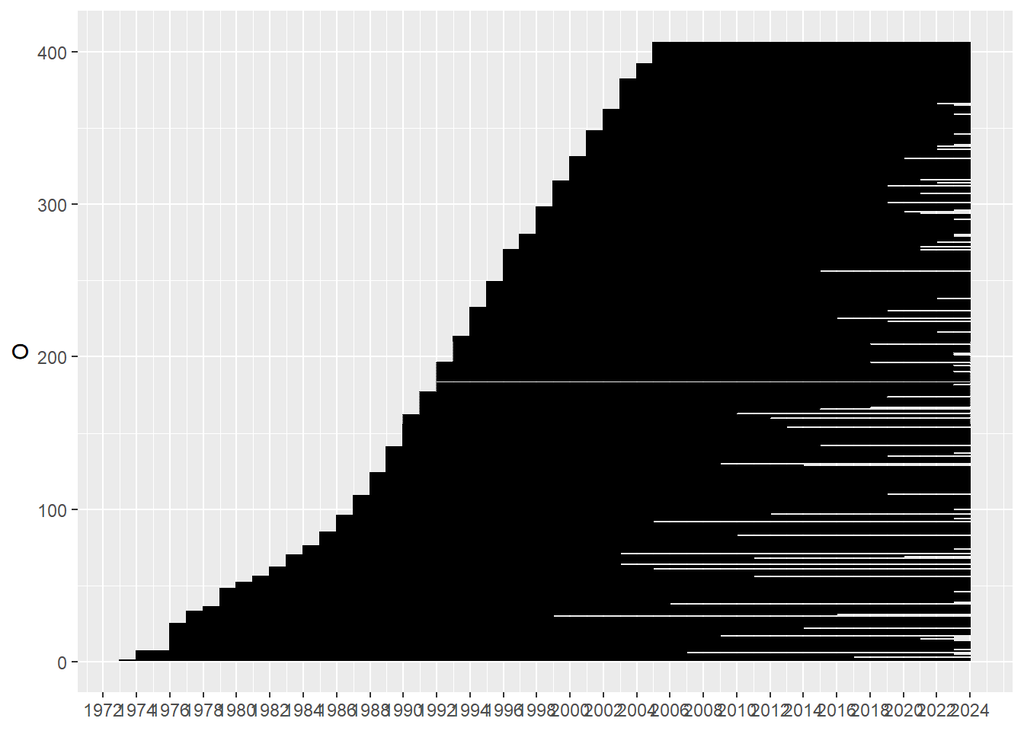

```r
LocationData %>%
  filter(N_yrs_surveyed >= 20,
         Northing < 450000,
         Northing > 0,
         Easting > 300000) %>%
  arrange(First_year_surveyed ) %>%
  mutate(O = rank( First_year_surveyed,
                   ties.method = 'random') ) %>%
  ggplot(aes(y = O ))+
  geom_errorbarh(aes(xmin= First_year_surveyed,
                     xmax = Last_year_surveyed))+
  scale_x_continuous(breaks =seq(1970,2024, by=2))
```